# Initiation igraph

olivier

23 octobre 2019

Je vais reprendre pas mal de codes et des notes à partir du livre **Statistical Analysis of Network Data with R** de Kolaczyk et Csárdi.

Un reseau peu être “orienté” ou “non orienté” (*directed* et *undirected*). Notre cas mélange les deux puisque l’on a des relations ascendantes/descendantes et des relations horizontales ou est ce que les relations horizontales sont à considerés à double sens ?

# 1 Intro

## 1.1 Faire des graphs

Un graph est représenté formellement comme ceci : $G =(V,E)$

$V$ représente les *vertices* (ou moeuds/*nodes*) et $E$ les *edges* (liens ou *links*). Le nombre total de noeuds est appelé *order* et de liens *size*. Ces codifications et notions sont importantes car `igraph` les reprends pour nommer ses fonctions.

igraph adopte (principalement) une convention de codage de ces fonctions de ce type `nom.nom` et est prévu pour du R base.

```r
library(igraph)
```

Pour fabriquer des petits graphs à vocation de test ou pédagogique la fonction `graph.formula` est suffisante :

```r
# on fabrique un graph
g <- graph.formula(1-2, 1-3, 2-3, 2-4, 3-5, 4-5, 4-6,
                    4-7, 5-6, 6-7)
V(g) # retourne les noeuds
```

```
## + 7/7 vertices, named, from 23d55c7:
## [1] 1 2 3 4 5 6 7
```

```r
E(g) # retourne les liens
```

```
## + 10/10 edges from 23d55c7 (vertex names):
##  [1] 1--2 1--3 2--3 2--4 3--5 4--5 4--6 4--7 5--6 6--7
```

```r
class(g)
```

```
## [1] "igraph"
```

```r
class(V(g))
```

```
## [1] "igraph.vs"
```

```r
class(E(g))
```

```
## [1] "igraph.es"
```

Comme on peut le voir avec `class(V(g))` les fonctions d’igraph retourne une `class` d’objet et des declinaisons specifiques. Ce sont des objets (`OO`) de type S3 dans R qui ont donc leurs propres methodes dans les fonctions géneriques (comme `plot()`).

```r
print_all(g) # la structure de g
```

```
## IGRAPH 23d55c7 UN-- 7 10 --
## + attr: name (v/c)
## + edges (vertex names):
## 1 -- 2, 3
## 2 -- 1, 3, 4
## 3 -- 1, 2, 5
## 4 -- 2, 5, 6, 7
## 5 -- 3, 4, 6
## 6 -- 4, 5, 7
## 7 -- 4, 6
```

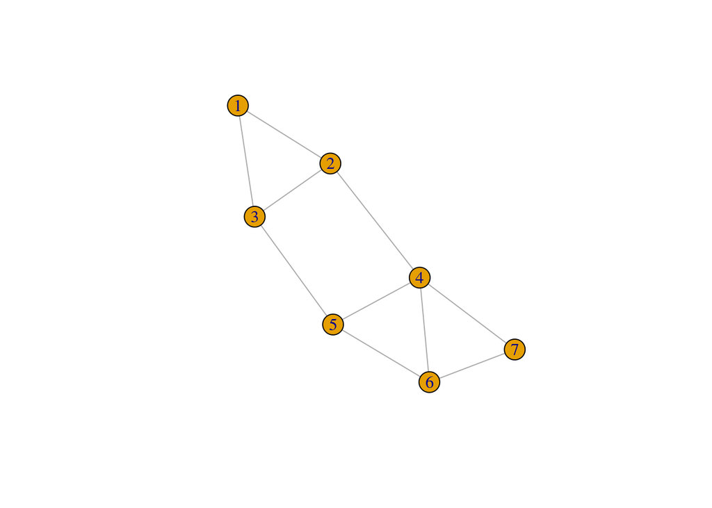

```r
plot(g) # un graphique
```

La premiere ligne : `IGRAPH 6a73c86 UN-- 7 10 --` indique un objet igraph UN comme *undirected* de 7 noeuds et 10 liens. Puis le liens sont représentés.

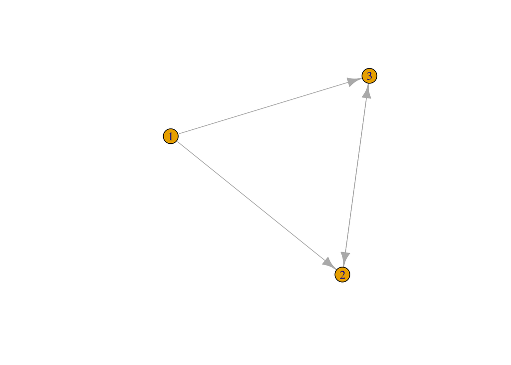

```r
dg <- graph.formula(1-+2, 1-+3, 2++3)
plot(dg)
```

```r
print_all(dg)
```

```
## IGRAPH 9de34fe DN-- 3 4 --
## + attr: name (v/c)
## + edges from 9de34fe (vertex names):
## [1] 1->2 1->3 2->3 3->2
```

Ici on a produit un graph orienté (DN) avec meme une double orientation : de 2 vers 3 et de 3 vers. Il est possible de remplacer ou d’obtenir les nom des noeuds :

```r
V(dg)$name # on prends les noms
```

```
## [1] "1" "2" "3"
```

```r
V(dg)$name <- c("Sam", "Mary", "Tom") # on les remplace
dg
```

```
## IGRAPH 9de34fe DN-- 3 4 --
## + attr: name (v/c)
## + edges from 9de34fe (vertex names):
## [1] Sam ->Mary Sam ->Tom  Mary->Tom  Tom ->Mary
```

`get.edgelist` retourne le graph dans une matrice de deux colonnes assez lisible et `get.adjacency` retourne une matrice de contingence via les noeuds (ce format est pratique pour les calculs).

```r
get.edgelist(g) #
```

```
##       [,1] [,2]
##  [1,] "1"  "2"
##  [2,] "1"  "3"
##  [3,] "2"  "3"
##  [4,] "2"  "4"
##  [5,] "3"  "5"
##  [6,] "4"  "5"
##  [7,] "4"  "6"
##  [8,] "4"  "7"
##  [9,] "5"  "6"
## [10,] "6"  "7"
```

```r
get.adjacency(g)
```

```
## 7 x 7 sparse Matrix of class "dgCMatrix"
##   1 2 3 4 5 6 7
## 1 . 1 1 . . . .
## 2 1 . 1 1 . . .
## 3 1 1 . . 1 . .
## 4 . 1 . . 1 1 1
## 5 . . 1 1 . 1 .
## 6 . . . 1 1 . 1
## 7 . . . 1 . 1 .
```

## 1.2 Faire des opérations sur les graphs

Bien que l’on puisse travailler avec le graph chargé on peut être interessé par des sous parties, rajouté des liens/noeuds etc.. On peut utiliser la fonction `induced.subgraph` :

```r
h <- induced.subgraph(g, 1:5)
print_all(h)
```

```
## IGRAPH dbf92c5 UN-- 5 6 --
## + attr: name (v/c)
## + edges from dbf92c5 (vertex names):
## [1] 1--2 1--3 2--3 2--4 3--5 4--5
```

On ne garde que les noeuds de 1 à 5 et les liens correspondant. Les opérateurs usuelles fonctionnent aussi.

```r
h <- g - vertices(c(6,7))  # ici on retire les noeuds 6 et 7
h <- h + vertices(c(6,7)) # là on les remets mais il manque les liens
g <- h + edges(c(4,6), c(4,7), c(5,6), c(6,7)) # que l' on rajoute
```

## 1.3 Décorer des graphs

On parle de *decorating*, cela correspond à rajouter des attributs (sur les noeuds, liens ou l’ensemble).

L’operateur `$` est pas mal utilisé et déjà un peu vu.

```r
V(g)$color <- "red"
g
```

```
## IGRAPH bef7bda UN-- 7 10 --
## + attr: name (v/c), color (v/c)
## + edges from bef7bda (vertex names):
##  [1] 1--2 1--3 2--3 2--4 3--5 4--5 4--6 4--7 5--6 6--7
```

L’attribut le plus fréquent pour les liens est le poid (*weighted*) :

```r
E(g)$weight <- runif(ecount(g))
```

On peut aussi nommer le graph :

```r
g$name <- "exemple"
print_all(g)
```

```
## IGRAPH bef7bda UNW- 7 10 -- exemple
## + attr: name (g/c), name (v/c), color (v/c), weight (e/n)
## + edges (vertex names):
## 1 -- 2, 3
## 2 -- 1, 3, 4
## 3 -- 1, 2, 5
## 4 -- 2, 5, 6, 7
## 5 -- 3, 4, 6
## 6 -- 4, 5, 7
## 7 -- 4, 6
```

### 1.3.1 Exemple sur un cas un peu plus complexe

le cas part de deux df mis dans un graph

```r
library(sand)
str(elist.lazega)
```

```
## 'data.frame':    115 obs. of  2 variables:
##  $ V1: Factor w/ 29 levels "V1","V10","V11",..: 1 12 12 12 12 12 12 21 21 21 ...
##  $ V2: Factor w/ 22 levels "V12","V15","V16",..: 4 22 3 4 8 11 14 5 10 13 ...
```

```r
str(v.attr.lazega)
```

```
## 'data.frame':    36 obs. of  9 variables:
##  $ Name     : Factor w/ 36 levels "V1","V10","V11",..: 1 12 23 31 32 33 34 35 36 2 ...
##  $ Seniority: int  1 2 3 4 5 6 7 8 9 10 ...
##  $ Status   : int  1 1 1 1 1 1 1 1 1 1 ...
##  $ Gender   : int  1 1 1 1 1 1 1 1 1 1 ...
##  $ Office   : int  1 1 2 1 2 2 2 1 1 1 ...
##  $ Years    : int  31 32 13 31 31 29 29 28 25 25 ...
##  $ Age      : int  64 62 67 59 59 55 63 53 53 53 ...
##  $ Practice : int  1 2 1 2 1 1 2 1 2 2 ...
##  $ School   : int  1 1 1 3 2 1 3 3 1 3 ...
```

```r
g.lazega <- graph.data.frame(elist.lazega, directed =  FALSE, vertices = v.attr.lazega)
g.lazega$name <- "exmple lazega"
```

```r
vcount(g.lazega) # 36 avocats
```

```
## [1] 36
```

```r
ecount(g.lazega) # 115 liens
```

```
## [1] 115
```

`list.vertex.attributes` retourne la liste des attributs des vertices

```r
list.vertex.attributes(g.lazega)
```

```
## [1] "name"      "Seniority" "Status"    "Gender"    "Office"    "Years"
## [7] "Age"       "Practice"  "School"
```

On fait la difference entre un graph qui ne peut avoir plus d’un lien entre deux noeuds (*simple graph*) et un graph où c’est le cas *multi-edged*.